# **Assignment 5: Dimensionality Reduction Techniques**

Here a dataset of parameters describing living conditions in different countries is studied. The variables include maternal mortality (Mat.Mor), life expectancy (Life.Exp), expected years of education (Edu.Exp) adolescent birth rate (ado.Birth), gross national income (GNI), ratio of labor force participation of females and males (Labo.FM), ratio of female and male populations with secondary education (Edu2.FM) and ratio of female representatives in parliament (Parli.F). Below a summay of the variables is shown. More information can be found from http://hdr.undp.org/en/content/human-development-index-hdi.

```r
# read the data set and check the structure
human = read.csv("data/human.csv")
summary(human)
```

```
##    Country             Edu2.FM          Labo.FM          Life.Exp
##  Length:155         Min.   :0.1717   Min.   :0.1857   Min.   :49.00
##  Class :character   1st Qu.:0.7264   1st Qu.:0.5984   1st Qu.:66.30
##  Mode  :character   Median :0.9375   Median :0.7535   Median :74.20
##                     Mean   :0.8529   Mean   :0.7074   Mean   :71.65
##                     3rd Qu.:0.9968   3rd Qu.:0.8535   3rd Qu.:77.25
##                     Max.   :1.4967   Max.   :1.0380   Max.   :83.50
##     Edu.Exp           GNI            Mat.Mor         Ado.Birth
##  Min.   : 5.40   Min.   :   581   Min.   :   1.0   Min.   :  0.60
##  1st Qu.:11.25   1st Qu.:  4198   1st Qu.:  11.5   1st Qu.: 12.65
##  Median :13.50   Median : 12040   Median :  49.0   Median : 33.60
##  Mean   :13.18   Mean   : 17628   Mean   : 149.1   Mean   : 47.16
##  3rd Qu.:15.20   3rd Qu.: 24512   3rd Qu.: 190.0   3rd Qu.: 71.95
##  Max.   :20.20   Max.   :123124   Max.   :1100.0   Max.   :204.80
##     Parli.F
##  Min.   : 0.00
##  1st Qu.:12.40
##  Median :19.30
##  Mean   :20.91
##  3rd Qu.:27.95
##  Max.   :57.50
```

As can be seen from the figure below, many of the variables are skewed. The skewedness is negative for F/M -ratio in secondary education and labor force as well as life expectancy. This means that although in many countries the ratios and life expectancy are rather high, the mean is lowered by a few countries having very low ratios or life expectancy. The skewedness is also quite natural as both, the ratio and life expectancy have a rather set upper limit that cannot be exceeded. The distribution of female representatives in parliament is positively skewed, meaning that it is more typical for countries to have parliament where majority of representatives are men and the parliaments with female majority are rarities. Gross national income, maternal mortality and adolescent birth rate have strong positively skewed distributions. Expected years of education has the only nearly normal distribution.

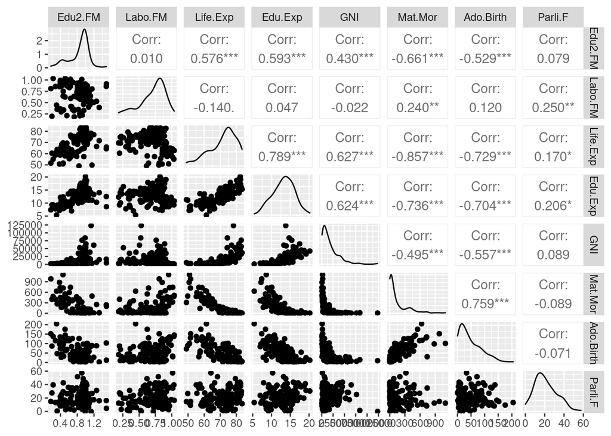

```r
# visualize the data
ggpairs(human[-1], lower = list(combo = wrap("facethist", bins = 20)))
```

The correlations between variables are better seen in the correlation matrix below. Education and gross national income seem to increase life expectancy. In the countries where maternal mortality and adolescent birth rate are high, the life expectancy is lower. These two also correlate positively, meaning that where adolescent birth rate is high, also maternal mortality is more common. High adolescent birth rates and maternal mortality seems to also go together with low education and gross national income. Quite interestingly, the ration in labor force and parliament do not seem to correlate strongly with any of the other variables.

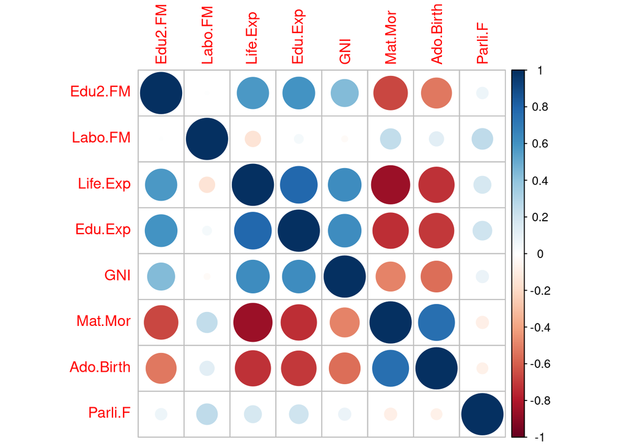

```r
# compute the correlation matrix and visualize it with corrplot
cor(human[-1]) %>% corrplot
```

As seen from the correlation matrix, some of the variables are highly correlated. Therefore it could be useful to perform Principal Component Analysis in order to reduce the dimensions of the dataset and find the linear combination(s) accounting for most of the variation in the data. First PCA is performed on the non-standardized dataset. It is already seen in the warning messages when plotting that there is a large difference in the variances of the variables. Non-standardized dataset where variables have very different scales and magnitudes lead typically to dominance of one variable with the largest variance. This is the case also here: the gross national income domianates the scaling of the figure, leaving the arrows representing other variables with length zero and therefore they are not plotted.

```r
# perform principal component analysis (with the SVD method)
pca_human <- prcomp(human[-1])

# create a summary of pca_human
s <- summary(pca_human)

# rounded percentages of variance captured by each PC
pca_pr <- round(100*s$importance[2,], digits = 1)

# print out the percentages of variance
pca_pr
```

```
## PC1 PC2 PC3 PC4 PC5 PC6 PC7 PC8
## 100   0   0   0   0   0   0   0
```

[output not shown]

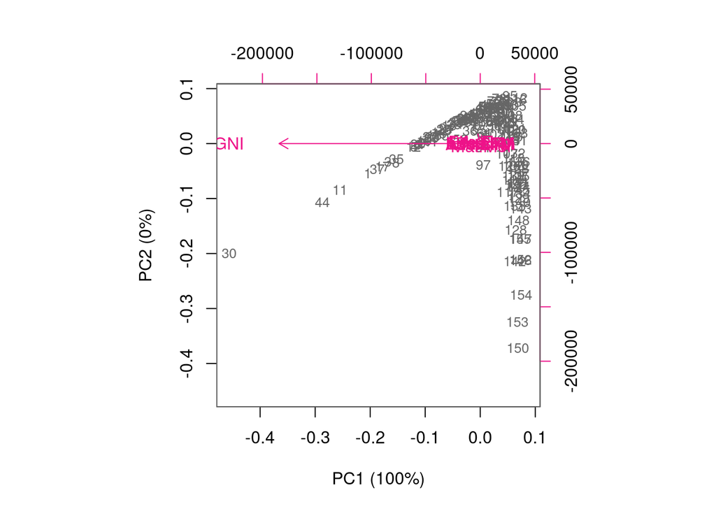

```r
# create object pc_lab to be used as axis labels
pc_lab <- paste0(names(pca_pr), " (", pca_pr, "%)")

# draw a biplot
biplot(pca_human, cex = c(0.8, 1), col = c("grey40", "deeppink2"), xlab = pc_lab[1], ylab = pc_lab[2])
```

It is wiser to do the PCA with standardized data and now the visualization is nicely centered around zero as seen in the figure below. The pink arrows representing the original variables show same correlations as already seen in the correlation matrix: life expectancy is correlated with education and gross national income (small angle between the arrows). They also correlate negatively with maternal mortality and adolescent birth rate (angle of 180 degrees). These arrows are nearly parallel to the PC1 axis, meaning that they do not considerably contribute to PC2. In contrast, female representatives in parliament and labor force ratio contribute mostly to PC2 and not considerably to PC1. The slight tilt in the Parli.F -arrow could, however, indicate that the ratio of females in parliament is likely to be higher in countries with higher education, higher gross national income and higher life expectancy.

The summary of the components (below) shows that the first PC explains roughly half (54 %) of the variance. The second PC explains an additional 16 %. In order to explain over 90 % of the variance, in total five components are needed, but 70 % explained by the two first components can also be regarded as sufficient. Visualizing PC1 and PC2 on a biplot (below), some clustering is revealed, although the groups are not very tight. Dots labeled with small numbers, representing industrialized countries such as most European countries, are concentrated to the negative (left) side of the x-axis (PC1) whereas larger numbers, representing less developed, for example many African countries, are to the positive (right) side. The PC1 can thus be seen to represent life expectancy and the variables correlated with it. PC2 does not contribute to the life expectancy but increases the spread along the y-axis.

Although it was nice to learn about Principal Component Analysis, it mainly confirms what is already seen from the correlation matrix. However, I can see its usefulness in analyzing multivariate datasets.

```r
# standardize the variables
human_std <- scale(human[-1])

# perform principal component analysis (with the SVD method)
pca_human_std <- prcomp(human_std)

# create a summary of pca_human_std
s <- summary(pca_human_std)

# rounded percentages of variance captured by each PC
pca_pr <- round(100*s$importance[2,], digits = 1)

# print out the percentages of variance
pca_pr
```

```
##  PC1  PC2  PC3  PC4  PC5  PC6  PC7  PC8
## 53.6 16.2  9.6  7.6  5.5  3.6  2.6  1.3
```

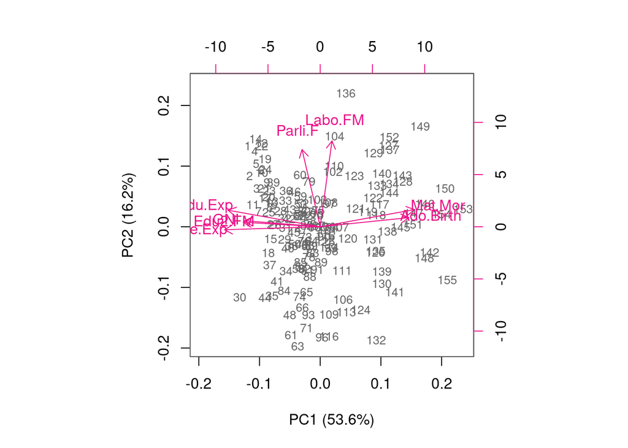

```r
# create object pc_lab to be used as axis labels
pc_lab <- paste0(names(pca_pr), " (", pca_pr, "%)")

# draw a biplot
biplot(pca_human_std, cex = c(0.8, 1), col = c("grey40", "deeppink2"), xlab = pc_lab[1], ylab = pc_lab[2])
```

[figure not shown]